# Spiritual Healing: Meta-Analysis

Intercessory Prayer, and Other Remote Healing Modalities

W. Kyle Hamilton

2018-04-17

This file documents the analyses conducted for Hamilton, & Coburn (2017) *Spiritual Healing: Meta-Analysis*

Analyses were conducted to examine the effect of spiritual healing on associated health outcomes relative to control. The effect size is the standarised mean difference (hedges g).

The operationalization of spiritual healing is defined for this project as the remote purposeful intervention by one or more persons aimed to cure or aid in healing of another person or group of persons by means of focused intention. Some healers attribute healing to God, Christ, other “higher powers”, spirits, cosmic forces, biological healing energies, forces residing in the healer, energies latent in the healee. All studies included here involve some form of distance healing.

## Data and Effect Sizes

```r
prayer.health.es <- escalc(measure="SMD", n1i = ES_MEANS_1_1, m1i = ES_MEANS_1_2, sd1i = ES_MEANS_1_3,
                            n2i = ES_MEANS_2_1, m2i = ES_MEANS_2_2, sd2i = ES_MEANS_2_3,
                           data=prayer.health.data, slab=STUDY_1 )
prayer.health.es$n1i = prayer.health.es$ES_MEANS_1_1
prayer.health.es$m1i = prayer.health.es$ES_MEANS_1_2
prayer.health.es$sd1i = prayer.health.es$ES_MEANS_1_3
prayer.health.es$n2i = prayer.health.es$ES_MEANS_2_1
prayer.health.es$m2i = prayer.health.es$ES_MEANS_2_2
prayer.health.es$sd2i = prayer.health.es$ES_MEANS_2_3

prayer.health.es$yi <- replmiss(prayer.health.es$yi,
                                with(prayer.health.es, (1 - 3/(4*(n1i+n2i-2) - 1)) * dval))
prayer.health.es$vi <- replmiss(prayer.health.es$vi,
                                with(prayer.health.es, 1/n1i+ 1/n2i + yi^2/(2*(n1i+n2i))))
#prayer.health.es$dval <- replmiss(prayer.health.es$dval,
#                               with(prayer.health.es, tval * sqrt(1/n1i + 1/n2i)))
prayer.health.es$sei <- sqrt(prayer.health.es$vi)
```

## Meta-Analysis

```r
res.prayer.health <- rma(yi, vi, data=prayer.health.es)
res <- rma(yi, vi, data=prayer.health.es)
res.prayer.health
```

```
##
## Random-Effects Model (k = 23; tau^2 estimator: REML)
##
## tau^2 (estimated amount of total heterogeneity): 0.0000 (SE = 0.0031)
## tau (square root of estimated tau^2 value):      0.0014
## I^2 (total heterogeneity / total variability):   0.01%
## H^2 (total variability / sampling variability):  1.00
##
## Test for Heterogeneity:
## Q(df = 22) = 20.8143, p-val = 0.5322
##
## Model Results:
##
## estimate      se     zval    pval    ci.lb   ci.ub
##  -0.0163  0.0261  -0.6261  0.5313  -0.0674  0.0348
##
## ---
## Signif. codes:  0 '***' 0.001 '**' 0.01 '*' 0.05 '.' 0.1 ' ' 1
```

## Methods

A random effects meta-analysis was conducted using the *metafor* package 2.0.0 (Viechtbauer, 2010) to examine the effect of spiritual healing on associated health outcomes relative to control. The effect size is the standarised mean difference (hedges g).

## Results | What is the impact of the spiritual healing on associated health outcomes relative to control?

A random effects meta-analysis was conducted (k=23) to explore the association between the spiritual healing group and the control group on associated health outcomes. The average difference in associated health outcomes was g=-0.02 (p=0.531, 95% CI [-0.07, 0.03]). It is important to note that a p>.05 indicates lack of evidence of an effect (i.e. uncertainty) rather than evidence of no effect unless confidence intervals are sufficently narrow to rule out a clinically meaningful effect. The results of this analysis are summarised below.

Meta-Analysis Summary Table

|  | g | se | p | CI Lower | CI Upper | k |
| --- | --- | --- | --- | --- | --- | --- |
| associated health outcomes - spiritual healing | -0.016 | 0.026 | 0.531 | -0.067 | 0.035 | 23 |

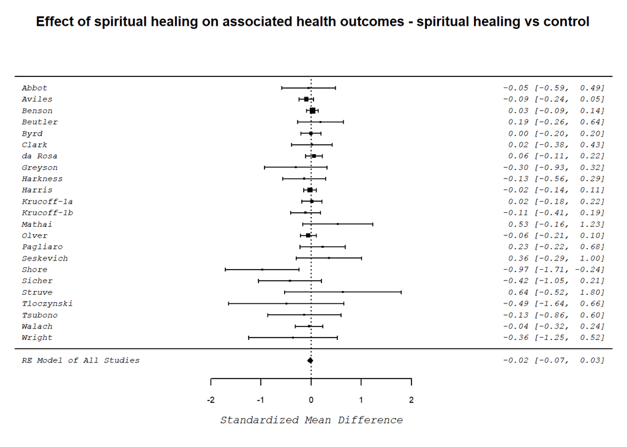

## Results | Does the strength of the effect vary across studies?

A Cochran’s Q test was conducted to examine whether variations in the observed effect are likely to be attributable soley to sampling error (Q<sub>(df=22)</sub>=20.81, p=0.532). There is no evidence that the true effect size varies between studies. The I<sup>2</sup> statistics indicates the proportion of variance in the observed effect attributable to sampling error. In this instance, the I<sup>2</sup> = 0.01%. Note, this statistic is not an absolute measure of heterogeneity (although it is often interpreted as such). We strongly advise against using rules of thumb such as “small”, “medium” or “large” when interpreting I<sup>2</sup> values. Instead, researchers increasingly argue that the information provided credibility or prediction intervals is more useful in understanding the heterogeneity of true effect sizes in meta-analysis. In this instance the 95% credibility intervals are -0.07,0.03. That is, it is estimated that 95% of true effect sizes fall between g=-0.07 and g=0.03.

Heterogeneity statistics are summarised below

Heterogeneity Summary Table

|  | $\tau$<sup>2</sup> | se $\tau$<sup>2</sup> | Q | p | I<sup>2</sup> | Credibility Lower | Credibility Upper |
| --- | --- | --- | --- | --- | --- | --- | --- |
| associated health outcomes - spiritual healing | 0 | 0.003 | 20.814 | 0.532 | 0.012 | -0.067 | 0.035 |

## Publication Bias

A funnel plot was generated to allow for visual inspection of funnel plot asymmetry that can indicate reporting biases (e.g. publication bias or outcome selection bias).

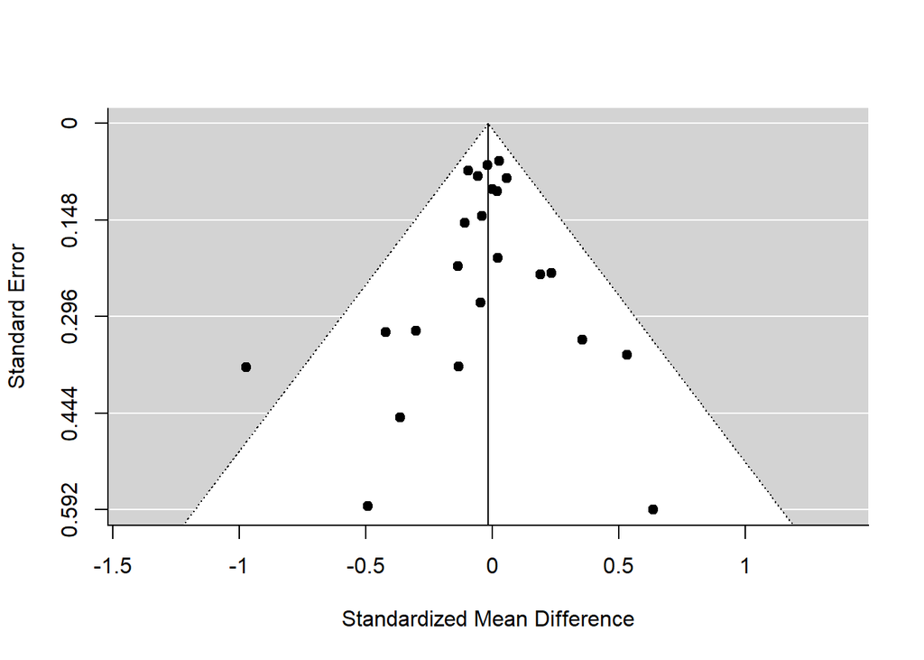

An Egger’s test was conducted to detect funnel plot asymmetry (z=-0.57,p= 0.57).

### Vevea and Hedges Weight Function Model

```r
weightfunct(effect=prayer.health.es$yi, v=prayer.health.es$vi, steps=c(0.50, 1.00), table=TRUE)
```

```
##
## Unadjusted Model (k = 23):
##
## tau^2 (estimated amount of total heterogeneity): 0.0000 (SE = 0.0107)
## tau (square root of estimated tau^2 value):  0.0000
##
## Model Results:
##
##           estimate std.error  z-stat   p-val    ci.lb   ci.ub
## Intercept -0.01631    0.0298 -0.5474 0.58412 -0.07471 0.04209
##
## Adjusted Model (k = 23):
##
## tau^2 (estimated amount of total heterogeneity): 0.0000 (SE = 0.0506)
## tau (square root of estimated tau^2 value):  0.0000
##
## Model Results:
##
##              estimate std.error  z-stat    p-val    ci.lb   ci.ub
## Intercept   -0.009956   0.04383 -0.2272 0.820297 -0.09585 0.07594
## 0.5 < p < 1  1.173157   0.64468  1.8198 0.068795 -0.09038 2.43670
##
## Likelihood Ratio Test:
## X^2(df = 1) = 0.08529359, p-val = 0.77025
##
## Number of Effect Sizes per Interval:
##
##                    Frequency
## p-values <0.5             10
## 0.5 < p-values < 1        13
```

## Technical Details

### Loaded Packages

```
##                _
## platform       x86_64-w64-mingw32
## arch           x86_64
## os             mingw32
## system         x86_64, mingw32
## status
## major          3
## minor          4.4
## year           2018
## month          03
## day            15
## svn rev        74408
## language       R
## version.string R version 3.4.4 (2018-03-15)
## nickname       Someone to Lean On
```

### Total Run Time

```
## Time difference of 1.747333 secs
```